# Scales

September 2021

## Information processing

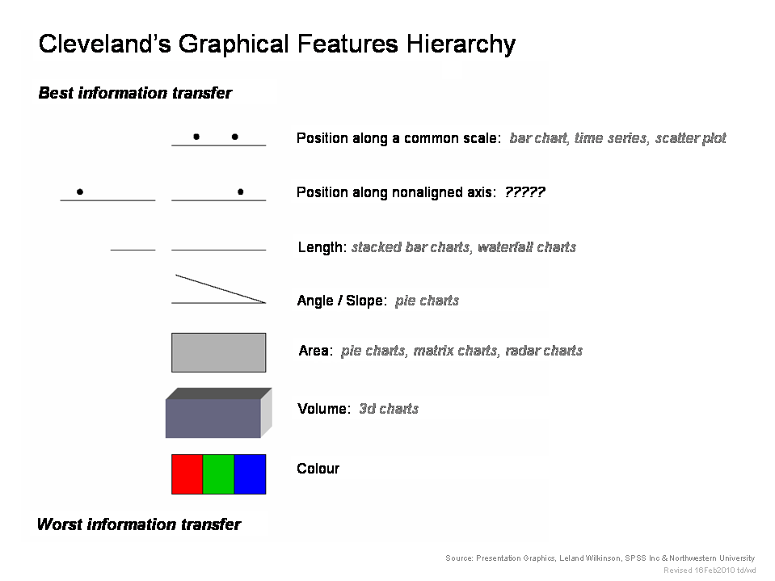

## Scales

- The top of the hierarchy involves putting things on scales
- But what scale do we use?
  - Are our data anchored to zero?
    - If so, are we interested in differences or ratios?
  - Are they anchored somewhere else?

## Anchors

## Anchors

- Anchors matter
- Your choice should be thoughtful and clear

## Utter problem algae

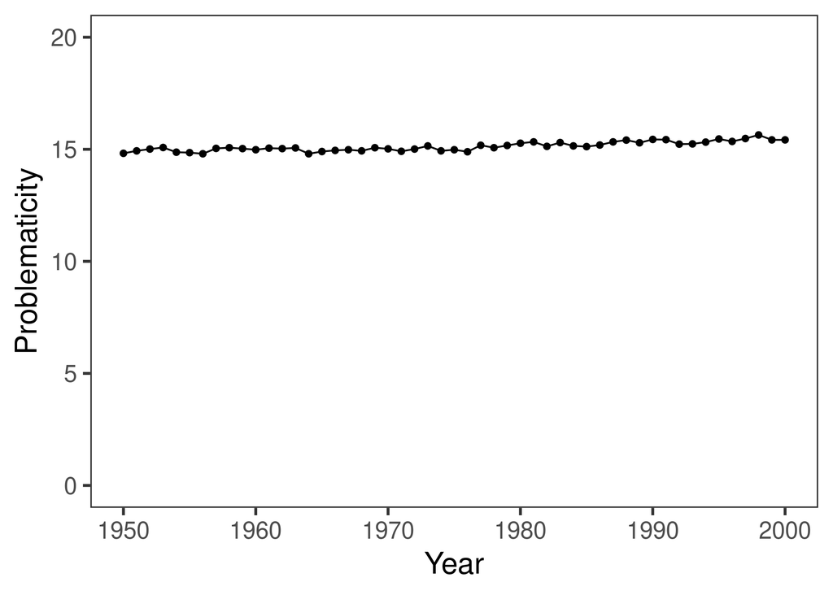

## Global temperature

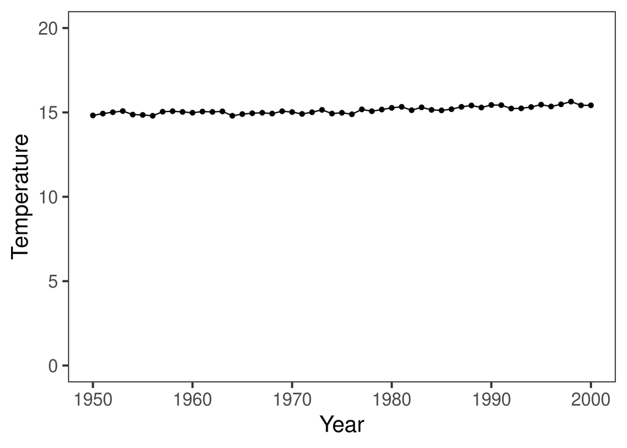

## Global temperature

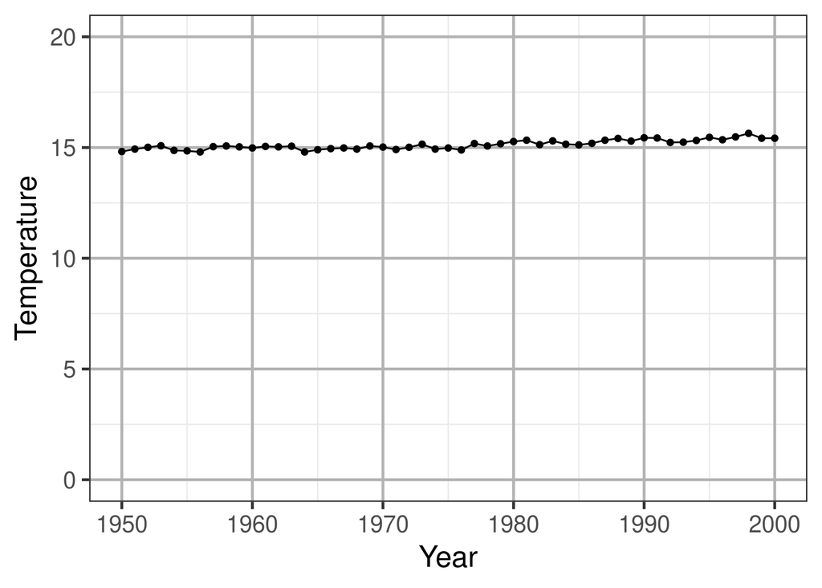

## Global temperature

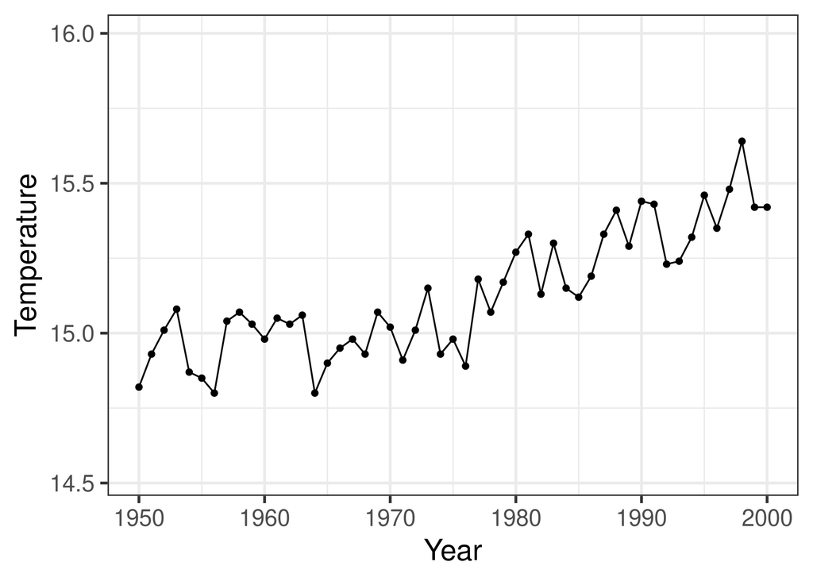

## Global temperature

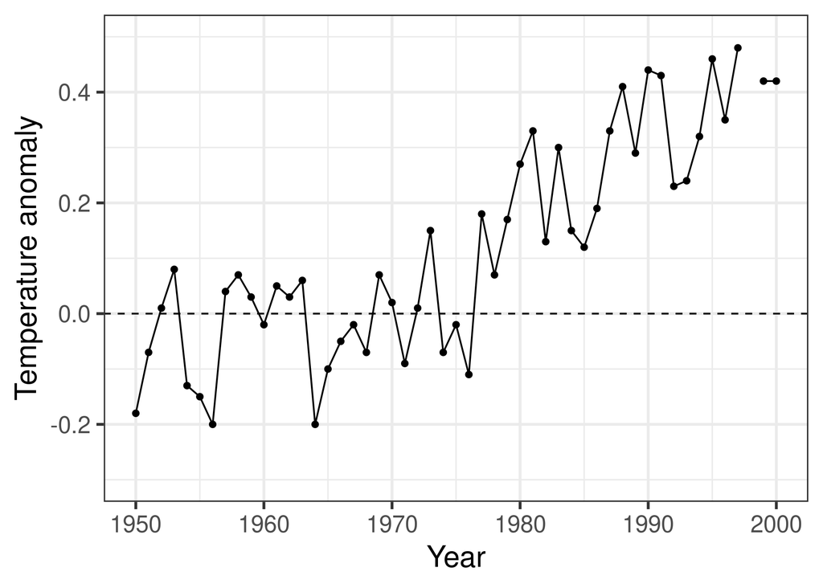

## Global temperature

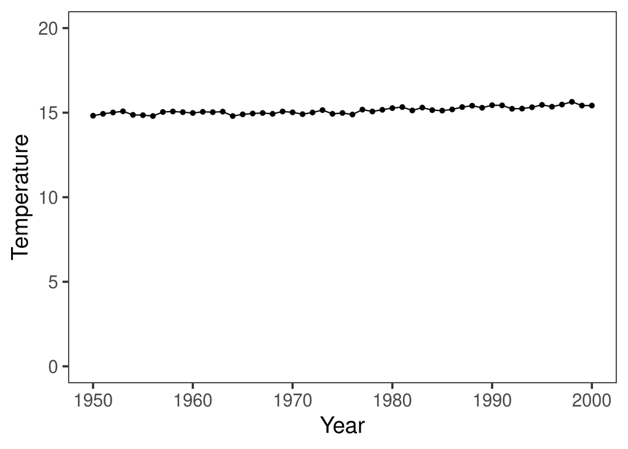

## Global temperature

- [Data](https://datahub.io/core/global-temp/r/annual.csv)
- Code: clean; plot

## Area and volume

## Area and volume

- Where does area lie on Cleveland’s scale?
  - It depends how you use it
  - Area can signal meaning

## Magazine circulation (advertisement)

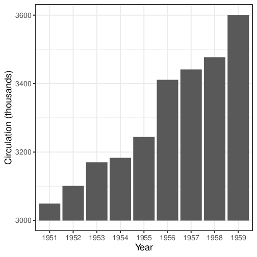

## Magazine circulation (total)

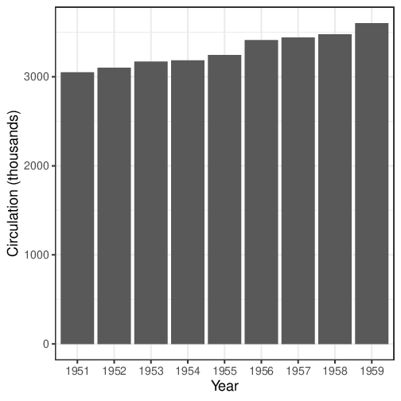

## Magazine circulation (trend)

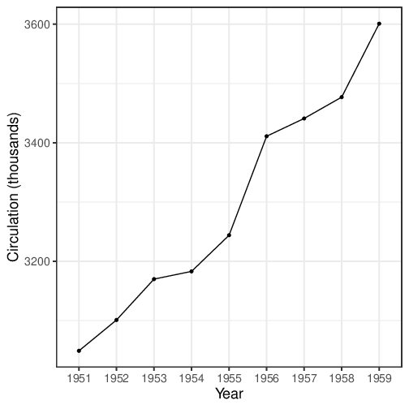

* Data * Code

## Area and volume

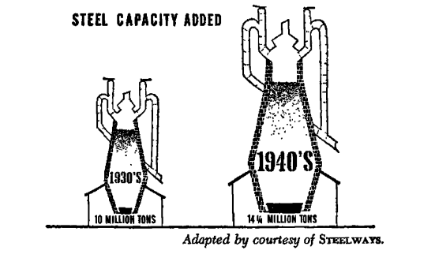

From [How to Lie with Statistics](https://en.wikipedia.org/wiki/How_to_Lie_with_Statistics)

## Advertisement lessons

- Use area to indicate fair comparisons
  - On a physical scale
- Areas that can be compared linearly should be preferred
  - Depends on importance of feature
- Avoid using (or hinting at) volume

## Other scales

## Other scales

- Log, log odds and log-ratio scales are often the most relevant
- We need to work to understand them well and communicate them clearly

## Physical quantities

- 1 is to 10 as 10 is to what?
- The **log scale** is often good for concrete quantities:
  - When zero means zero
  - When we are thinking about things that might be added together
    - But *not* when we actually want to add them together!

## Provinces of Canada

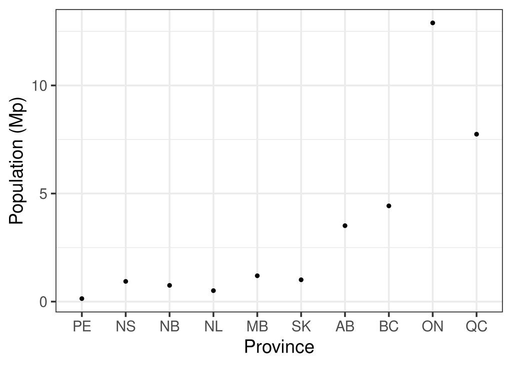

## Provinces of Canada

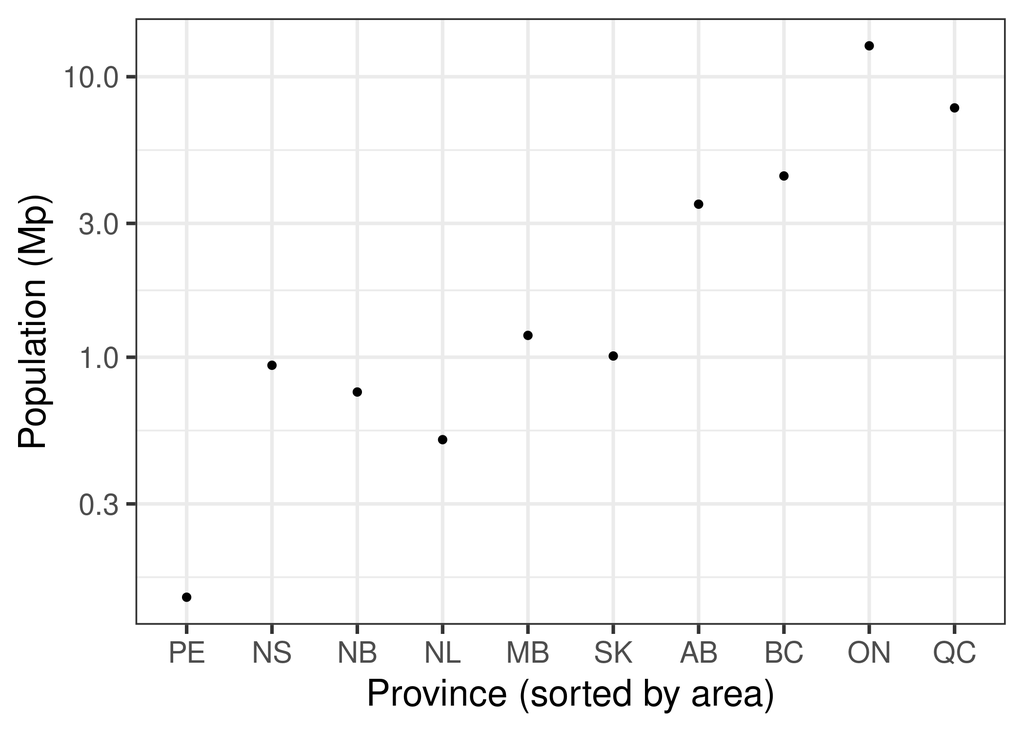

## Provinces of Canada

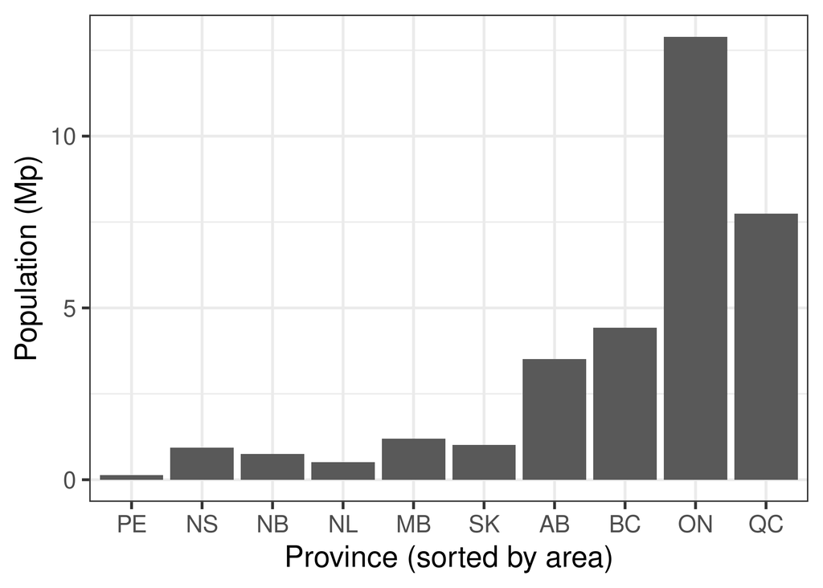

## Provinces of Canada

**BAD**

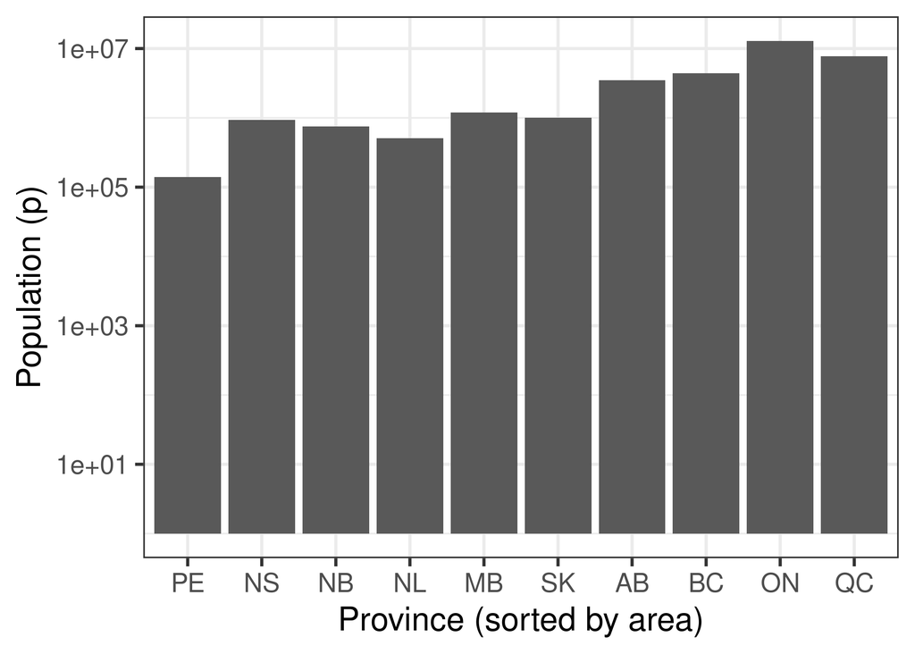

## Provinces of Canada

**BAD**

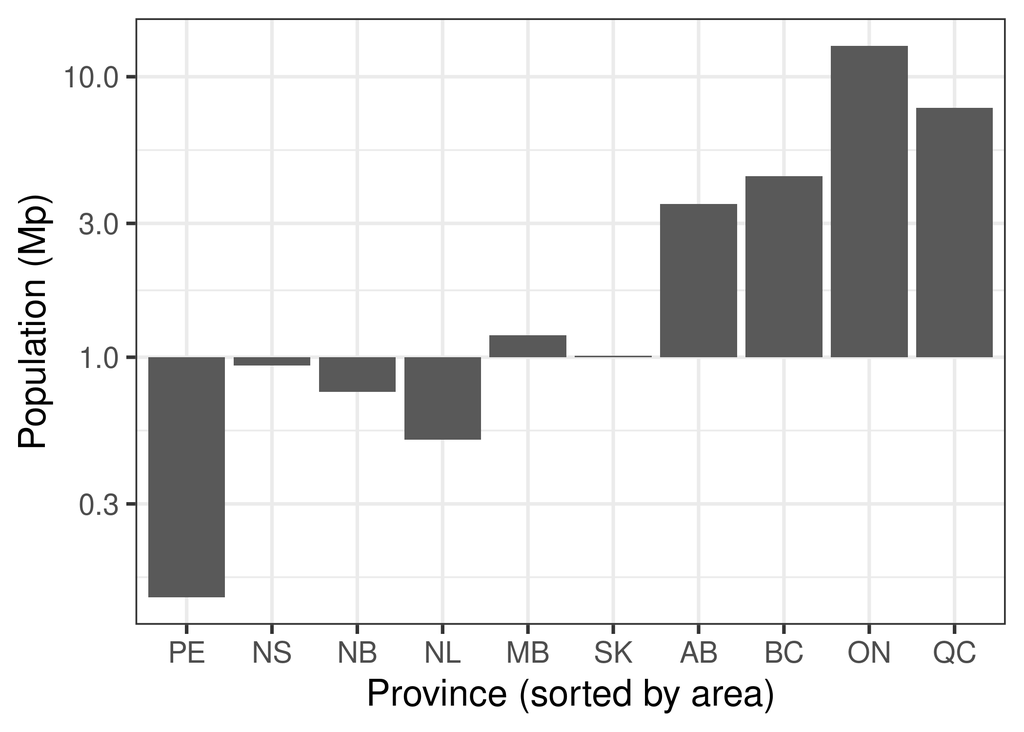

## Provinces of Canada

- Code: clean; plot
- Data

## Coronavirus incidence

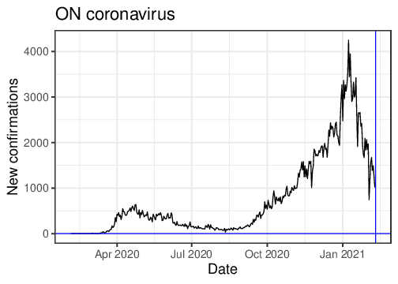

## Coronavirus incidence

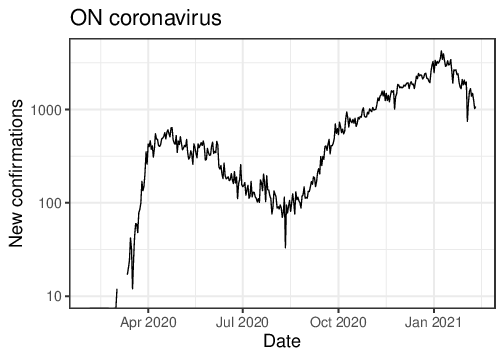

## Coronavirus incidence

- Code: clean; plot
- Data

## Example

- 20% of the adult population is unvaccinated, but they account for 60% of clinical diagnoses
- How much greater is their risk?

## Coronavirus vaccination

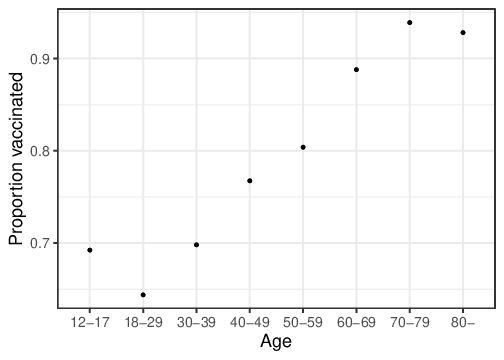

## Coronavirus vaccination

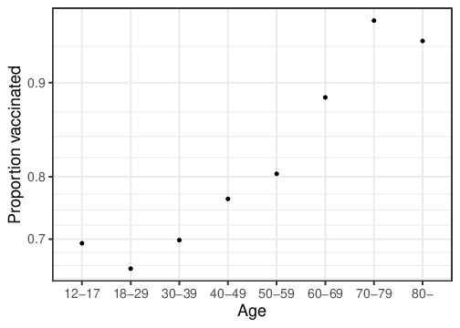

## Coronavirus vaccination

- Code
- Data

## Log ratios

- What is the problem with proportional change?
- Log ratios naturally extend the use of proportional change for small proportions

## Transformation lessons

- Transformations show valid alternative perspectives
  - Use human-friendly values when possible
- Different perspectives illuminate different questions
- Use visual clues to suggest whether your scales are additive

## More examples

## More examples

- Make plots quantitatively representative when you can

## PCA plots scaled by component importance

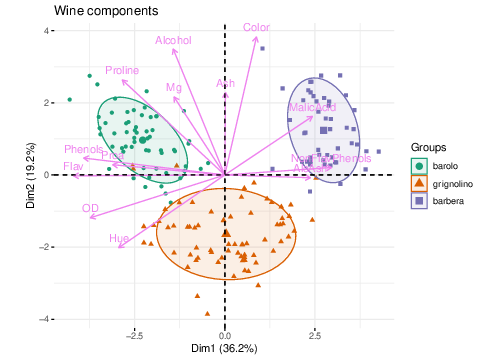

## PCA plots scaled by component importance

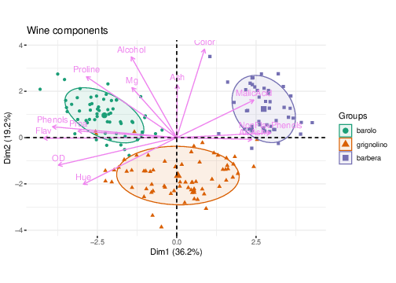

## Area proportional to quantity represented

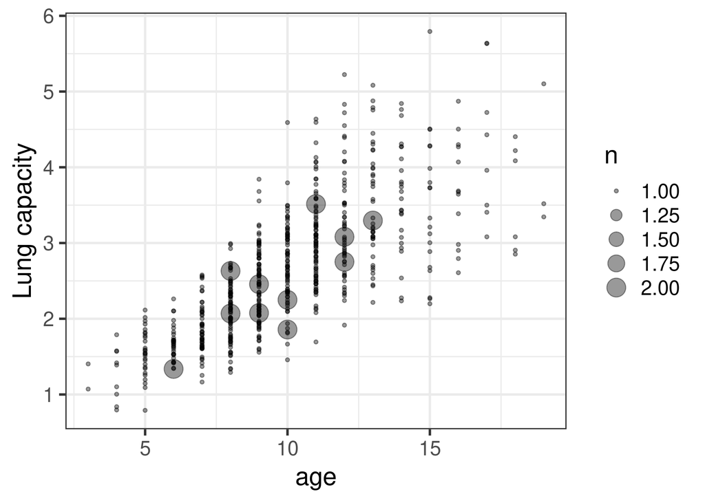

## Area proportional to quantity represented

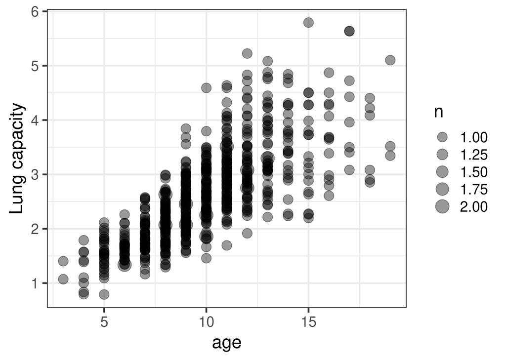